# Lab 8: Hypothesis Testing

**For this lab, it will be helpful to have a copy of the knitted version of this document to answer the questions as much of it is written using mathematical notation that may be difficult to read when the document is not knitted. For your convenience, a pdf of this document is in the lab folder on blackboard. Please ignore the code used to generate the figures in this lab.**

## Lab Goals

The purpose of this lab is to explore hypothesis testing for an unknown population mean, $\mu$, when $\bar X_n \sim N(\mu,\sigma/\sqrt{n})$. There are three main topics in the lab:

1. how to form a rejection region at a given significance level
2. how to calculate a p-value
3. how to calculate the power of a test (or choose $n$ to get a desired power)

## Recap of “psychic” example in lecture

In class, Dr. Basu used the binomial distribution to test whether or not he was psychic. Each student was supposed to choose one of the four colors red, blue, yellow and green. Dr. Basu’s task was to correctly guess the colors chosen by students. What were the basic ideas behind this test?

$$X \sim Binomilla(n,p) \quad \text{with known n and unknown p}$$

1. The **null hypothesis** is that Dr. Basu is not psychic, meaning he is just random guessing. If he were random guessing, then he would only have a 1 in 4 chance of guessing the correct color for each person in the class, so $H_0:p=1/4$ (where $p$ is the probability of his being right on any single guess).

$$X \sim Binomial(n, 0.25)$$

2. We would like to test whether Dr. Basu is psychic. This implies that the actual probability of Dr. Basu guessing the correct number for a given student is greater than what we would expect by random guessing. This establishes the **alternative hypothesis** of our test, $H_a: p > 0.25$ Dr. Basu *is* psychic.
3. He repeated the experiment $n=89$ times. Under the null hypothesis, we would expect him to get, on average, $0.25 \times 89\approx22$ correct. We will decide to reject $H_0$ if we have enough evidence in favor of $H_a$ over $H_0$. What does “evidence in favor of $H_a$ over $H_0$” look like? That depends on the form of $H_a$. In this case, $H_a:p>0.25$, so if the number of correct predictions Dr. Basu made is a lot bigger than $22$, that would lead us to reject $H_0$ in favor of $H_a$. How do we determine a specific cutoff for what “a lot bigger” means? We determine the distribution of the test statistic under $H_0$ and then choose the cutoff so that the probability of rejecting $H_0$ when $H_0$ is true is no more than $\alpha$, the desired **significance level** of the test. The set of values (of the test statistic) that would lead to our test rejecting $H_0$ in favor of $H_a$ is called the **rejection region**.

$$P(X > x_{rejection}) = \alpha = 0.05$$

```r
for(i in 8:12){
print(paste0(i, ": ",pbinom(i, 30, 0.25, lower.tail = F)))
}
```

```
## [1] "8: 0.326400849275959"
## [1] "9: 0.196593363050489"
## [1] "10: 0.10572812269266"
## [1] "11: 0.0506582800515518"
## [1] "12: 0.0215936408798555"
```

## Overview of hypothesis testing using a rejection region

*Step 1.* Identify null and alternative hypotheses.

*Step 2.* Determine distribution of the test statistic under the null hypothesis.

*Step 3.* Determine rejection region based on (1) and (2) and the desired significance level $\alpha$ chosen for this test.

*Step 4.* Compute test statistic on the particular sample of data you collected. Does this fall in rejection region? If so, reject $H_0$ in favor of $H_a$. If not, fail to reject $H_0$ in favor of $H_a$.

*Step 5.* Check assumptions.

## Part I of lab

We go through Step 1 to Step 4, with a different kind of alternative hypothesis and when test statistic is normal. We will skip Step 5 for now since we’ll see how to check normality in a future lab.

### Step 1: Choosing alternative hypothesis

Depending on the particular problem you are studying, there are three types of alternative hypothesis to consider about the population mean $\mu$ (in “psychic” example, $p$ is the population mean of the Bernoulli distribution).

A1) $H_{a}$: $\mu \neq \mu_0$ (“two-sided alternative”)

A2) $H_{a}$: $\mu > \mu_0$ (used in “psychic” example with $\mu_0$ = 0.25)

A3) $H_{a}$: $\mu < \mu_0$

If in the “psychic” example, we were interested in whether Dr. Basu was random guessing or not, we should have chosen $H_a:p\neq0.25$. But since being psychic would mean specifically that $p>0.25$, we chose this alternative instead.

### Step 2: Distribution of test statistic under null hypothesis

In the “psychic” example, we based the test of whether to reject $H_0$ in favor of $H_a$ on the distribution of a test statistic under the assumption that $H_0$ is true. This is the standard framework for hypothesis testing.

For the example given in class, $H_0$ states that $p = 0.25$. The null hypothesis indicates that for any single student there is a 0.25 chance that Dr. Basu will succeed in guessing his/her chosen color correctly. This indicates that the number of correct guesses in 89 trials (89 students) has a Binomial(89,0.25) distribution under the assumption that Dr. Basu is not psychic ($H_0$). Thus, in the example given in class, this was the appropriate null distribution for the number of correct guesses.

In many situations, we wish to perform a hypothesis test about the population mean $\mu$, and the most common choice of test statistic in this context is the sample mean, $\bar X_n$. For this lab, we will assume that $\bar X_n \sim N(\mu, \sigma/\sqrt{n})$. This is approximately true when (i) the Central Limit Theorem holds or when (ii) the individual $X_i$ are themselves approximately normal and independent of each other. Under the null hypothesis that $H_0:\mu=\mu_0$, we have that $\bar X_n \sim N(\mu_0, \sigma/\sqrt{n})$.

#### Example: Hard Alcohol Content of Mixed Drinks in NYC

The industry standard for the amount of alcohol poured into many types of drinks is 1.5 oz. Regulators are interested in whether on average the amount of alcohol poured into drinks purchased in New York City is the industry standard. Forty bartenders are chosen at random from bars and restaurants in NYC. Each were asked to pour the amount of hard alcohol into a glass needed to make a mixed drink. The amount of hard alcohol poured by each bartender was recorded. The standard deviation of the amount of hard alcohol poured to make a drink in NYC is known to be about 0.39 oz. The sample mean of the amount of hard alcohol poured for the mixed drink by the 40 bartenders was 1.7 oz.

1. Define $\mu$ and determine the null and alternative hypotheses of this study.

> $\mu = 1.5$
2. What is the approximate distribution of the sample mean under the null hypothesis for this study?

> $X \sim N(1.5, \frac{0.39}{\sqrt{40}})$

### Step 3: Determine rejection region

In the “psychic” example, we decided that if the test statistic (number of correct guesses) was higher than a certain cutoff, we should reject $H_0$ in favor of $H_a$. The set of values above this cutoff are called the rejection region for the test.

For any test, the **rejection region** is the range of values of the test statistic for which $H_0$ will be rejected in favor of $H_a$. The rejection region is based on three things:

1. The desired significance level, $\alpha$, of the test. This is the largest that we will allow the probability of making a Type I error (rejecting $H_0$ when $H_0$ is true) to be.

> $\alpha = 0.05$
2. The alternative hypothesis. Looking at the alternative tells us whether high values or low values (or both) of the test statistic would be considered evidence against the null and *in favor of the alternative*.
3. The distribution of the test statistic under the null (from Step 2) tells us what the cutoff values should be for the rejection region to make the test have significance level $\alpha$.

In class, the rejection region for $H_a: p > 0.25$ was $X \geq 30$. This rejection region guarantees that if $H_0$ is true, there is at most a 5% chance that $H_0$ will be rejected.

What are the rejection regions based on the sample mean for the three alternatives above?

A1) If $H_{a}$: $\mu \neq \mu_0$, $H_0$ will be rejected if the observed sample mean from our data, $\bar x_n$, is either a lot bigger or a lot smaller than what we would expect under $H_0$. How large is “a lot bigger” and how small is “a lot smaller”? These cutoffs come from considering the null distribution of $\bar X_n$ and the significance level $\alpha$. It’s easiest looking at a picture:

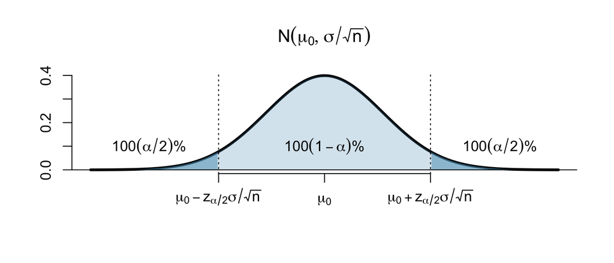

Reject $H_0$ if $\bar x_n$ is less than the $\alpha/2$ quantile (a.k.a., the $100(\alpha/2)$ percentile) of the distribution of $\bar X_n$ under $H_0$ *or* if $\bar x_n$ is greater than the $(1 - \alpha/2)$ quantile (a.k.a., the $100(1 - \alpha/2)$ percentile) of the distribution of $\bar X_n$ under $H_0$. We see from the picture that we reject if $\bar x_n$ is farther than $z_{\alpha/2}\sigma/\sqrt{n}$ from $\mu_0$:
$$|\bar x_n - \mu_0 | > z_{\alpha/2}\sigma/\sqrt{n}.$$
That is we reject if $\bar x_n > \mu_0+z_{\alpha/2}\sigma/\sqrt{n}$ *or* if $\bar x_n < \mu_0-z_{\alpha/2}\sigma/\sqrt{n}$.

A2) If $H_{a}$: $\mu > \mu_0$, $H_0$ will be rejected if the observed sample mean from our data, $\bar x_n$, is a lot bigger than what we would expect under $H_0$. How large is “a lot bigger”? The cutoff comes from considering the null distribution of $\bar X_n$ and the significance level $\alpha$. Again, it’s always best to draw a picture:

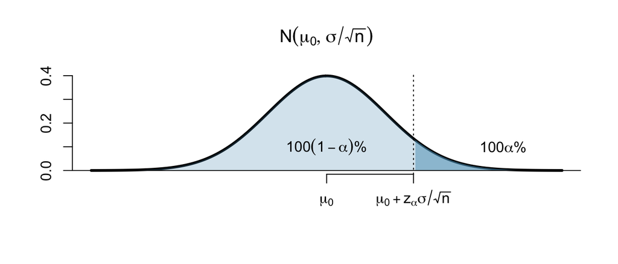

Reject $H_0$ if $\bar x_n\ge$ the $100(1 - \alpha)$ percentile of the distribution of $\bar X_n$ under $H_0$. We see from the picture that we reject if
$$\bar x_n > \mu_0 + z_{\alpha}\sigma/\sqrt{n}.$$

A3) If $H_{a}$: $\mu < \mu_0$, $H_0$ will be rejected if the observed sample mean from our data, $\bar x_n$, is a lot smaller than what we would expect under $H_0$. How small is “a lot smaller”? The cutoff comes from considering the null distribution of $\bar X_n$ and the significance level $\alpha$. Again, we draw a picture:

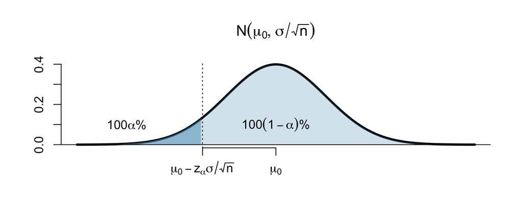

Reject $H_0$ if $\bar x_n$ $\leq$ $100\alpha$ percentile of the distribution of $\bar X_n$ under $H_0$. We see from the picture that we reject if
$$\bar x_n < \mu_0 - z_{\alpha}\sigma/\sqrt{n}.$$

#### Example: Hard Alcohol Content of Mixed Drinks in NYC

We continue with the next part of our example problem. Suppose the regulators want to perform the hypothesis test determined above at a significance level of 0.01.

3. What is the rejection region of this test?

```r
alpha <- 0.01
mu <- 1.5
sigma <- 0.39
n <- 40
SE <- sigma/sqrt(n)

(reject_lower <- qnorm(alpha/2, mu, SE))
```

```
## [1] 1.341163
```

```r
(reject_upper <- qnorm(1-alpha/2, mu, SE))
```

```
## [1] 1.658837
```

```r
(1-pnorm(1.7,mu,SE))*2
```

```
## [1] 0.001181281
```

> We **reject** the null hypothesis

## Overview of hypothesis testing using P-values

Instead of the rejection region approach, we now consider the (highly related) p-value approach to hypothesis testing.

*Step 1.* Identify null and alternative hypotheses.

*Step 2.* Determine distribution of the test statistic under the null hypothesis.

*Step 3.* Compute the p-value based on the particular sample of data you collected.

*Step 4.* Reject $H_0$ in favor of $H_a$ if p-value is smaller than desired significance level $\alpha$.

*Step 5.* Check assumptions.

The **p-value** of a test is the probability under the null hypothesis of seeing something as extreme or more extreme than what was actually observed.

## Part II of lab

We go through these steps (again, skipping step 5 for this lab) with alternative hypotheses A1 to A3 when the test statistic is normal.

### Step 1 and Step 2

Identical to Steps 1 and 2 in rejection region approach.

### Step 3: Compute the p-value

We observed $\bar x_n$ and want to know how likely it is for $\bar X_n \sim N(\mu_0, \sigma/\sqrt{n})$ (this is the null distribution) for $\bar X_n$ to be as extreme or more extreme as $\bar x_n$. What does “extreme” mean? This is defined by the alternative hypothesis. Because A1 is the most complicated, we’ll do this last.

A2) $H_{a}$: $\mu > \mu_0$. In this case, “extreme” means being much larger than $\mu_0$. So we want to know the probability (calculated under $H_0$) that $\bar X_n$ would be as big as $\bar x_n$ (our observed value) or larger. That is, we want to know

$$P(\bar X_n > \bar x_n~|~H_0\text{ true})$$

Recalling that $H_0$ says that $\bar X_n\sim N(\mu_0,\sigma/\sqrt{n})$ we can draw a picture to show the probability we want:

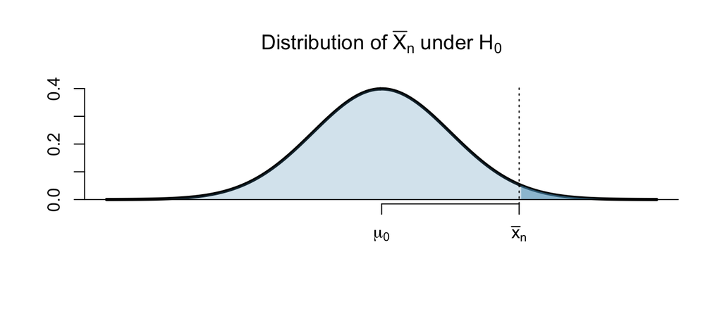

The p-value in this case is
$$P(\bar X_n > \bar x_n~|~H_0\text{ true}).$$
In R this is given by

```r
1 - pnorm(xbar, mu0, sigma / sqrt(n))
```

or we could standardize to z-values (to get same answer):

```r
zvalue = (xbar - mu0) / (sigma / sqrt(n)) # standardize according to null
1-pnorm(zvalue) # under null, 'zvalue' is a realization from a N(0,1)
```

A3) $H_{a}$: $\mu < \mu_0$. In this case, “extreme” means being much smaller than $\mu_0$. So we want to know the probability (calculated under $H_0$) that $\bar X_n$ would be as small as $\bar x_n$ (our observed value) or smaller. That is, we want to know

$$P(\bar X_n < \bar x_n~|~H_0\text{ true})$$

It’s always a good idea to draw a picture:

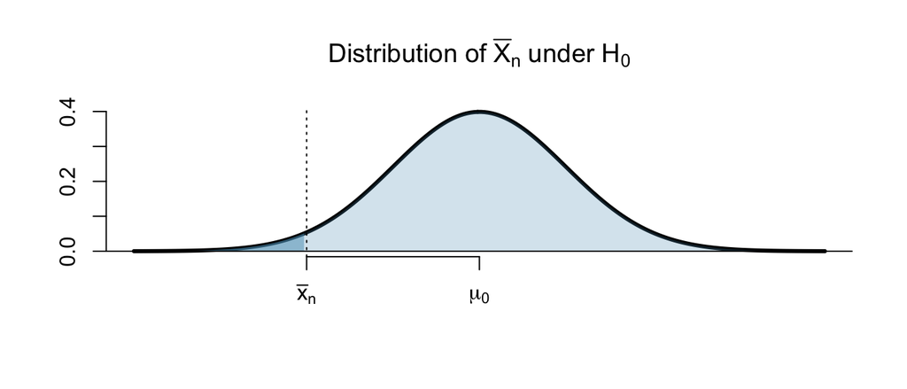

The p-value in this case is
$$P(\bar X_n < \bar x_n~|~H_0\text{ true}).$$
In R this is given by

```r
pnorm(xbar, mu0, sigma / sqrt(n))
```

or we could standardize to z-values (to get same answer):

```r
zvalue = (xbar - mu0) / (sigma / sqrt(n)) # standardize according to null
pnorm(zvalue) # under null, 'zvalue' is a realization from a N(0,1)
```

A1) $H_{a}$: $\mu \neq \mu_0$. In this case, “extreme” means either much larger or much smaller than $\mu_0$. So we want to know the probability (calculated under $H_0$) that $\bar X_n$ would be as far or farther from $\mu_0$ as we observed $\bar x_n$ to be. That is, we want to know if $|\bar x_n-\mu_0|$ is unusually high based on what we’d expect for $|\bar X_n-\mu_0|$ under $H_0$. Note that $H_0$ tells us that $\bar X_n-\mu_0\sim N(0,\sigma/\sqrt{n})$. Let’s draw a picture to show what we mean:

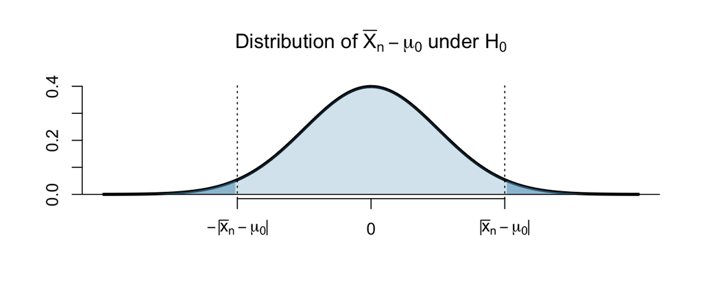

The p-value in this case is
$$P(\bar X_n-\mu_0 > |\bar x_n-\mu_0|\text{ or }\bar X_n-\mu_0 < -|\bar x_n-\mu_0|~|~H_0\text{ true}) = 2P(\bar X_n-\mu_0 > |\bar x_n-\mu_0|~|~H_0\text{ true}).$$

For calculating this probability, it’s easier to deal with the standard normal. Under the null,
$$\frac{\bar X_n-\mu_0}{\sigma/\sqrt{n}}\sim N(0,1),$$
so we want to know if we calculate
$$z_n=\frac{\bar x_n-\mu_0}{\sigma/\sqrt{n}},$$
we want to calculate
$$P( N(0,1) > |z_n| \text{ or } N(0,1) < -|z_n|) = 2 P(N(0,1) > |z_n|).$$
In R, this is given by

```r
2 * (1 - pnorm(abs(z)))
```

### P-value: Hard Alcohol Content of Mixed Drinks in NYC

1. What is the p-value of this test?
2. Based on the p-value, should we reject $H_0$?

## Power (Part III of lab)

The power of a test is the probability we will reject $H_0$ when it is false. If $H_0: \mu = \mu_0$ is false, a value of $\mu$ contained in the range of the alternative hypothesis must be the correct mean of $\bar X_n$. The power of a test cannot be calculated without specifying an alternative value of $\mu$ contained in the range of $H_a$. We call this value $\mu_a$. The power of a test is calculated under the assumption that $\bar X_n \sim N(\mu_a,\sigma/\sqrt{n})$ is the correct distribution of the sample mean.

Generally $\mu_a$ is chosen so that $|\mu_0 - \mu_{a}|$ represents the smallest difference between $\mu_0$ and $\mu$ for which you would like to reject $H_0$ at the calculated power level.

### Problem 2

In reference to problem 1, suppose that NYC officials don’t mind if the population mean amount of hard alcohol in a mixed drink in NYC is a bit higher than 1.5 oz, but they do want to make sure that they can detect when it is in truth 1.65 oz (or higher). That is, they want to make sure that when the population mean is in fact 1.65oz, their testing will have a high probability of revealing this fact. Thus, to calculate the power of the test, we’ll set $\mu_a$ = 1.65 oz. and $\bar X_{40} \sim N(1.65, 0.39/\sqrt{40})$.

1. Approximate the power of the test performed in Problem 1 using the following steps:

```
i) Simulate 100,000 independent samples from the distribution of $\bar X_{40}$ under the alternative hypothesis that $\mu_a = 1.65$, i.e. $\bar X_{40} \sim N(1.65, 0.39/\sqrt{40})$.
```

2. Based on these 100,000 samples, estimate the probability that the sample mean of the study will fall into the rejection region determined in Problem 1(b). This is the power of the test when the sample size, n, is equal to 40.
2. Calculate the actual power of this test, $P(\bar X_n \leq 1.34 \text{ or } \bar X_n \geq 1.66~|~\mu=1.65)$ using the `pnorm()` function in R.
3. Re-run the code from part (b) using different values of n. By trial and error, find the smallest value of $n$ such that the power of the test is greater than or equal to 0.9.